# Regression and model validation

Susanna Jernberg

# Linear regression and model validation

### Overview of the data

The data constitutes of 7 variables that are gender (factor), age (integer), attitude (integer) that describes, attitude toward statistics, deep (numeric) describing exam questions related to deep learning, stra (numeric) describing questions related to strategic learning and surf (numeric) describing questions related to surface learning and Points (integer) that refers to exam points.

```r
learning_data<-read.csv(file="D:/Users/E1002220/Opinnot/Data science/IODS-project/data/learning2014_data.csv", sep="\t")
library(dplyr)
library(GGally)
str(learning_data)
```

```
## 'data.frame':    166 obs. of  7 variables:
##  $ gender  : Factor w/ 2 levels "F","M": 1 2 1 2 2 1 2 1 2 1 ...
##  $ Age     : int  53 55 49 53 49 38 50 37 37 42 ...
##  $ Attitude: int  37 31 25 35 37 38 35 29 38 21 ...
##  $ deep    : num  3.58 2.92 3.5 3.5 3.67 ...
##  $ stra    : num  3.38 2.75 3.62 3.12 3.62 ...
##  $ surf    : num  2.58 3.17 2.25 2.25 2.83 ...
##  $ Points  : int  25 12 24 10 22 21 21 31 24 26 ...
```

```r
dim(learning_data)
```

```
## [1] 166   7
```

Below are the summary plots of the data. There are some difference between the male and female students, for instance there seems to be a small difference in the attitude between the genders, male studens having a bit higher attitude than females. This can be seen both in the boxplots and their means and the overal distribution of the responses.

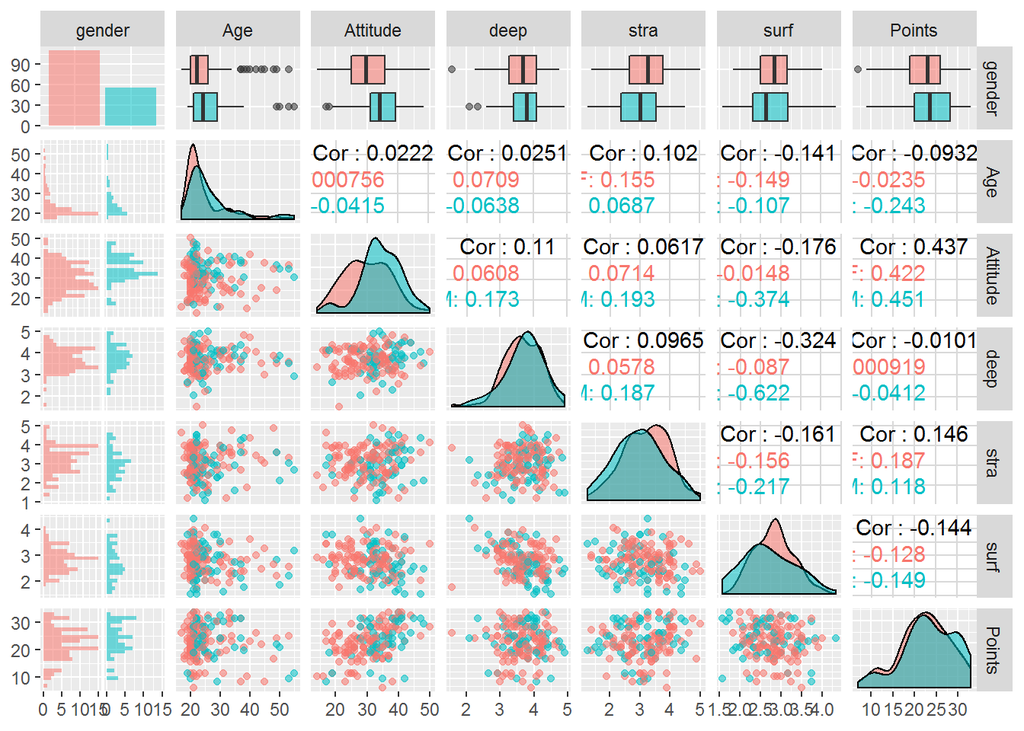

```r
p<-ggpairs(learning_data, mapping = aes(col=gender, alpha= 0.3), lower=list(combo=wrap("facethist", bins=20)))
p
```

```r
summary(learning_data)
```

```
##  gender       Age           Attitude          deep            stra
##  F:110   Min.   :17.00   Min.   :14.00   Min.   :1.583   Min.   :1.250
##  M: 56   1st Qu.:21.00   1st Qu.:26.00   1st Qu.:3.333   1st Qu.:2.625
##          Median :22.00   Median :32.00   Median :3.667   Median :3.188
##          Mean   :25.51   Mean   :31.43   Mean   :3.680   Mean   :3.121
##          3rd Qu.:27.00   3rd Qu.:37.00   3rd Qu.:4.083   3rd Qu.:3.625
##          Max.   :55.00   Max.   :50.00   Max.   :4.917   Max.   :5.000
##       surf           Points
##  Min.   :1.583   Min.   : 7.00
##  1st Qu.:2.417   1st Qu.:19.00
##  Median :2.833   Median :23.00
##  Mean   :2.787   Mean   :22.72
##  3rd Qu.:3.167   3rd Qu.:27.75
##  Max.   :4.333   Max.   :33.00
```

### Fitting the linear regression to the data and relationship between the variables.

Here the aim is to find variables that are explaining best the variable Points. Based on the summary plots, attitude, strategic learning and surface learning seem to be the variables with highest correlation with the points. So these will first be used in building the model.

```r
my_model<-lm(Points ~ Attitude + stra + surf, data=learning_data)
summary(my_model)
```

```
##
## Call:
## lm(formula = Points ~ Attitude + stra + surf, data = learning_data)
##
## Residuals:
##      Min       1Q   Median       3Q      Max
## -17.1550  -3.4346   0.5156   3.6401  10.8952
##
## Coefficients:
##             Estimate Std. Error t value Pr(>|t|)
## (Intercept) 11.01711    3.68375   2.991  0.00322 **
## Attitude     0.33952    0.05741   5.913 1.93e-08 ***
## stra         0.85313    0.54159   1.575  0.11716
## surf        -0.58607    0.80138  -0.731  0.46563
## ---
## Signif. codes:  0 '***' 0.001 '**' 0.01 '*' 0.05 '.' 0.1 ' ' 1
##
## Residual standard error: 5.296 on 162 degrees of freedom
## Multiple R-squared:  0.2074, Adjusted R-squared:  0.1927
## F-statistic: 14.13 on 3 and 162 DF,  p-value: 3.156e-08
```

```r
my_model<-lm(Points ~ Attitude + stra, data=learning_data)
summary(my_model)
```

```
##
## Call:
## lm(formula = Points ~ Attitude + stra, data = learning_data)
##
## Residuals:
##      Min       1Q   Median       3Q      Max
## -17.6436  -3.3113   0.5575   3.7928  10.9295
##
## Coefficients:
##             Estimate Std. Error t value Pr(>|t|)
## (Intercept)  8.97290    2.39591   3.745  0.00025 ***
## Attitude     0.34658    0.05652   6.132 6.31e-09 ***
## stra         0.91365    0.53447   1.709  0.08927 .
## ---
## Signif. codes:  0 '***' 0.001 '**' 0.01 '*' 0.05 '.' 0.1 ' ' 1
##
## Residual standard error: 5.289 on 163 degrees of freedom
## Multiple R-squared:  0.2048, Adjusted R-squared:  0.1951
## F-statistic: 20.99 on 2 and 163 DF,  p-value: 7.734e-09
```

### Diagnostic plots and model validation

There are always assumption about the data when certain model is being used. In linear regreassion model, the assumpiton are for instance, that the errors have a normal distribution, they are not correlated, have a constant variance and the size of the erros is not dependent on the explanatory variables. The plots below allow us to explore these assumptions. The plot with residuals vs. fitted values tells if the variance is constant. This is true for this model because there is no pattern in the points and they are quite randomly distributed in the figure. QQ plot shows if the errors are normally distirbuted. In this case they are because the points in the plot follow the line in the middle quite well. Only in the beginning of the line, one could say that there is something weird in the distribution. The plot with standardized residuals vs. levarage shows the impact of a single observation on the model. In this case, no single observation stands out from the figure and thus affects the model too much.

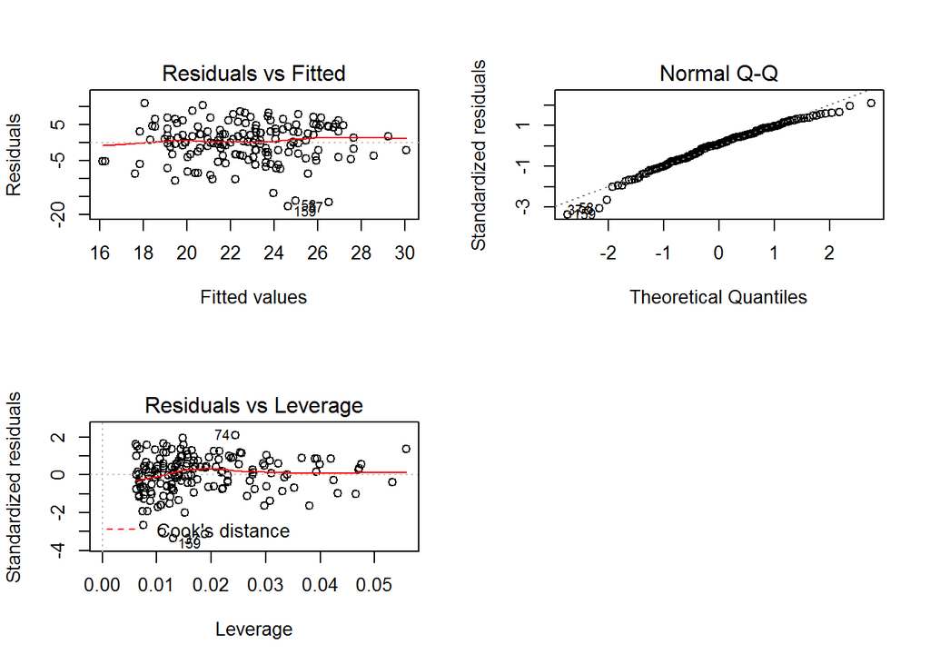

```r
par(mfrow=c(2,2))
plot(my_model, which=c(1,2,5))
```